# 01.01_clean_donorinfo

- Version: 1.0
- Last update: 2023-12-08
- Short description: This notebook is used to: clean, explore and transform the donor information data. Some first (quick) pre-checks have been applied as well.

## Main Part

### Checking df basics

|  | donor_id | name | age | sex | apo_e4_allele | education_years | age_at_first_tbi | longest_loc_duration | cerad | num_tbi_w_loc | dsm_iv_clinical_diagnosis | control_set | nincds_arda_diagnosis | ever_tbi_w_loc | race | hispanic | act_demented | braak | nia_reagan |
| --- | --- | --- | --- | --- | --- | --- | --- | --- | --- | --- | --- | --- | --- | --- | --- | --- | --- | --- | --- |
| 0 | 326765665 | H14.09.078 | 87 | M | N | 16 | 0 | Unknown or N/A | 0 | 0 | No Dementia | 31 | No Dementia | N | White | Not Hispanic | No Dementia | 1 | 1 |
| 1 | 326765656 | H14.09.069 | 95-99 | M | N | 17 | 12 | 1-2 min | 2 | 1 | No Dementia | 26 | No Dementia | Y | White | Not Hispanic | No Dementia | 5 | 2 |
| 2 | 326765654 | H14.09.067 | 85 | M | Y | 10 | 72 | < 10 sec | 3 | 1 | Vascular | 25 | Dementia, Type Unknown | Y | White | Not Hispanic | Dementia | 4 | 2 |
| 3 | 467056391 | H15.09.103 | 90-94 | F | N | 11 | 87 | < 10 sec | 0 | 1 | No Dementia | 52 | No Dementia | Y | White | Not Hispanic | No Dementia | 4 | 0 |
| 4 | 309335447 | H14.09.010 | 100+ | M | Y | 16 | 0 | Unknown or N/A | 3 | 0 | Alzheimer's Disease Type | 28 | Possible Alzheimer'S Disease | N | White | Not Hispanic | Dementia | 4 | 2 |

#### Donor Information: Info

```
<class 'pandas.core.frame.DataFrame'>
RangeIndex: 107 entries, 0 to 106
Data columns (total 19 columns):
 #   Column                     Non-Null Count  Dtype
---  ------                     --------------  -----
 0   donor_id                   107 non-null    int64
 1   name                       107 non-null    object
 2   age                        107 non-null    object
 3   sex                        107 non-null    object
 4   apo_e4_allele              100 non-null    object
 5   education_years            107 non-null    int64
 6   age_at_first_tbi           107 non-null    int64
 7   longest_loc_duration       107 non-null    object
 8   cerad                      107 non-null    int64
 9   num_tbi_w_loc              107 non-null    int64
 10  dsm_iv_clinical_diagnosis  107 non-null    object
 11  control_set                107 non-null    int64
 12  nincds_arda_diagnosis      107 non-null    object
 13  ever_tbi_w_loc             107 non-null    object
 14  race                       107 non-null    object
 15  hispanic                   107 non-null    object
 16  act_demented               107 non-null    object
 17  braak                      107 non-null    int64
 18  nia_reagan                 107 non-null    int64
dtypes: int64(8), object(11)
memory usage: 16.0+ KB
```

#### Donor Information: Describe - Numerical

|  | donor_id | education_years | age_at_first_tbi | cerad | num_tbi_w_loc | control_set | braak | nia_reagan |
| --- | --- | --- | --- | --- | --- | --- | --- | --- |
| count | 107.000 | 107.000 | 107.000 | 107.000 | 107.000 | 107.000 | 107.000 | 107.000 |
| mean | 326495420.607 | 14.150 | 20.822 | 1.477 | 0.607 | 28.178 | 3.421 | 1.598 |
| std | 38286865.104 | 3.227 | 30.350 | 1.085 | 0.711 | 15.699 | 1.727 | 0.856 |
| min | 309335438.000 | 6.000 | 0.000 | 0.000 | 0.000 | 1.000 | 0.000 | 0.000 |
| 25% | 309335464.500 | 12.000 | 0.000 | 1.000 | 0.000 | 15.000 | 2.000 | 1.000 |
| 50% | 309335493.000 | 14.000 | 0.000 | 1.000 | 0.000 | 28.000 | 3.000 | 1.000 |
| 75% | 326765669.500 | 16.000 | 23.500 | 2.000 | 1.000 | 41.500 | 5.000 | 2.000 |
| max | 467056409.000 | 21.000 | 89.000 | 3.000 | 3.000 | 55.000 | 6.000 | 3.000 |

#### Donor Information: Describe - Object

|  | name | age | sex | apo_e4_allele | longest_loc_duration | dsm_iv_clinical_diagnosis | nincds_arda_diagnosis | ever_tbi_w_loc | race | hispanic | act_demented |
| --- | --- | --- | --- | --- | --- | --- | --- | --- | --- | --- | --- |
| count | 107 | 107 | 107 | 100 | 107 | 107 | 107 | 107 | 107 | 107 | 107 |
| unique | 107 | 15 | 2 | 2 | 8 | 6 | 4 | 2 | 2 | 1 | 2 |
| top | H14.09.078 | 90-94 | M | N | Unknown or N/A | No Dementia | No Dementia | N | White | Not Hispanic | No Dementia |
| freq | 1 | 28 | 63 | 80 | 61 | 56 | 56 | 54 | 105 | 107 | 57 |

### Correcting records based on Allen Institute documentation

Update TBI information for four donors who were initially thought not to have had a TBI. Here is the specific changes that are made from the original file on the website based on new information:

- tbiInfo[donorInfo name=="H14.09.072",1] = "Y"
- tbiInfo[donorInfo name=="H14.09.072",2] = 50
- tbiInfo[donorInfo name=="H14.09.072",3] = 1
- tbiInfo[donorInfo name=="H14.09.072",4] = "10 sec - 1 min"
- tbiInfo[donorInfo name=="H14.09.018",1] = "Y"
- tbiInfo[donorInfo name=="H14.09.018",2] = 75
- tbiInfo[donorInfo name=="H14.09.018",3] = 1
- tbiInfo[donorInfo name=="H14.09.018",4] = "3-5 min"
- tbiInfo[donorInfo name=="H14.09.038",1] = "Y"
- tbiInfo[donorInfo name=="H14.09.038",2] = 64
- tbiInfo[donorInfo name=="H14.09.038",3] = 1
- tbiInfo[donorInfo name=="H14.09.038",4] = "10 sec - 1 min"
- tbiInfo[donorInfo name=="H14.09.034",1] = "Y"
- tbiInfo[donorInfo name=="H14.09.034",2] = 85
- tbiInfo[donorInfo name=="H14.09.034",3] = 1
- tbiInfo[donorInfo name=="H14.09.034",4] = "3-5 min"

Source: [Link](https://github.com/AllenInstitute/agedbrain/blob/master/Code01_ReadInDataAndFormat.r)

### Checking: Missing Values

```
donor_id                     0
name                         0
age                          0
sex                          0
apo_e4_allele                7
education_years              0
age_at_first_tbi             0
longest_loc_duration         0
cerad                        0
num_tbi_w_loc                0
dsm_iv_clinical_diagnosis    0
control_set                  0
nincds_arda_diagnosis        0
ever_tbi_w_loc               0
race                         0
hispanic                     0
act_demented                 0
braak                        0
nia_reagan                   0
dtype: int64
```

- Seven missing values for **apo_e4_allele**

Checking values of apo_e4_allele:

```
apo_e4_allele
N    80
Y    20
Name: count, dtype: int64
```

|  | donor_id | name | age | sex | apo_e4_allele | education_years | age_at_first_tbi | longest_loc_duration | cerad | num_tbi_w_loc | dsm_iv_clinical_diagnosis | control_set | nincds_arda_diagnosis | ever_tbi_w_loc | race | hispanic | act_demented | braak | nia_reagan |
| --- | --- | --- | --- | --- | --- | --- | --- | --- | --- | --- | --- | --- | --- | --- | --- | --- | --- | --- | --- |
| 6 | 326765676 | H14.09.089 | 89 | F | NaN | 12 | 13 | 10 min - 1 hr | 3 | 1 | Vascular | 43 | Dementia, Type Unknown | Y | White | Not Hispanic | Dementia | 6 | 3 |
| 15 | 309335452 | H14.09.015 | 81 | M | NaN | 16 | 23 | > 1 hr | 1 | 2 | No Dementia | 36 | No Dementia | Y | White | Not Hispanic | No Dementia | 1 | 1 |
| 29 | 309335479 | H14.09.042 | 95-99 | F | NaN | 11 | 0 | Unknown or N/A | 3 | 0 | Alzheimer's Disease Type | 8 | Possible Alzheimer'S Disease | N | White | Not Hispanic | Dementia | 5 | 3 |
| 34 | 309335497 | H14.09.060 | 86 | F | NaN | 12 | 0 | Unknown or N/A | 2 | 0 | No Dementia | 20 | No Dementia | N | Non-white | Not Hispanic | No Dementia | 4 | 2 |
| 41 | 309335481 | H14.09.044 | 87 | F | NaN | 14 | 0 | Unknown or N/A | 2 | 0 | Alzheimer's Disease Type | 9 | Probable Alzheimer'S Disease | N | White | Not Hispanic | Dementia | 6 | 2 |
| 54 | 326765674 | H14.09.087 | 100+ | F | NaN | 19 | 89 | < 10 sec | 2 | 1 | Alzheimer's Disease Type | 42 | Possible Alzheimer'S Disease | Y | White | Not Hispanic | Dementia | 5 | 2 |
| 88 | 309335493 | H14.09.056 | 100+ | F | NaN | 17 | 0 | Unknown or N/A | 3 | 0 | Alzheimer's Disease Type | 18 | Possible Alzheimer'S Disease | N | White | Not Hispanic | Dementia | 5 | 3 |

Replace missing values in the apo_e4_allele column with "Unknown":

```
apo_e4_allele
N          80
Y          20
Unknown     7
Name: count, dtype: int64
```

### Checking: Duplicates

```
Duplicate count: 0
```

### Check Data Type Consistency

- Checking value consistency for categorical columns.
- Checking unique values for each object type column to identify any inconsistencies.

```
{'age': array(['87', '95-99', '85', '90-94', '100+', '89', '78', '83', '82', '77',
        '81', '88', '84', '86', '79'], dtype=object),
 'sex': array(['M', 'F'], dtype=object),
 'apo_e4_allele': array(['N', 'Y', 'Unknown'], dtype=object),
 'longest_loc_duration': array(['Unknown or N/A', '1-2 min', '< 10 sec', '10 min - 1 hr',
        '10 sec - 1 min', '> 1 hr', '3-5 min', '6-9 min'], dtype=object),
 'dsm_iv_clinical_diagnosis': array(['No Dementia', 'Vascular', "Alzheimer's Disease Type",
        'Multiple Etiologies', 'Other or Unknown Cause', 'Other Medical'],
       dtype=object),
 'nincds_arda_diagnosis': array(['No Dementia', 'Dementia, Type Unknown',
        "Possible Alzheimer'S Disease", "Probable Alzheimer'S Disease"],
       dtype=object),
 'ever_tbi_w_loc': array(['N', 'Y'], dtype=object),
 'race': array(['White', 'Non-white'], dtype=object),
 'hispanic': array(['Not Hispanic'], dtype=object),
 'act_demented': array(['No Dementia', 'Dementia'], dtype=object)}
```

- The age column has some ranges like '95-99' and '90-94', and also values like '100+'.
- The longest_loc_duration column has various time intervals, including 'Unknown or N/A'.
- Other columns seem to have fairly consistent values, but it depends on the domain knowledge and expected values for the dataset.

We are also looking for columns with mix data types:

- For each value in a column, we check if the value is a numeric string (using the is_number helper function) or if it's one of the allowed outlier values (like "NA").
- If a value is found that is neither a numeric string nor an allowed outlier, the column is flagged as inconsistent.

```
Columns with inconsistent or mixed data types:
```

```
['name',
 'age',
 'sex',
 'apo_e4_allele',
 'longest_loc_duration',
 'dsm_iv_clinical_diagnosis',
 'nincds_arda_diagnosis',
 'ever_tbi_w_loc',
 'race',
 'hispanic',
 'act_demented']
```

### Check Distributions & Apply Binning

#### Age (of death) Value Counts

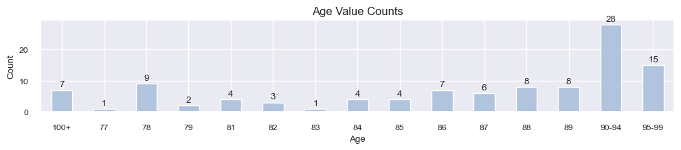

#### Age Binning

- We strive to categorize the age information in order to obtain a dataset that is evenly distributed, while also ensuring the preservation of the current groups: 90-94, 95-99, 100+.

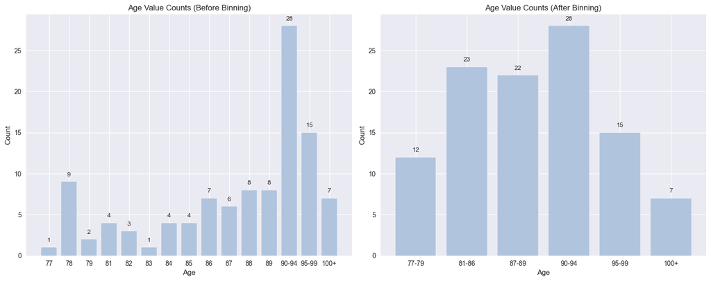

#### Age Cleaning

- We are also generating a new attribute called "age_clean" to retain the quantitative data of the age.
- We will use the median.

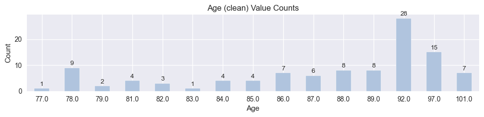

#### age_at_first_tbi value counts

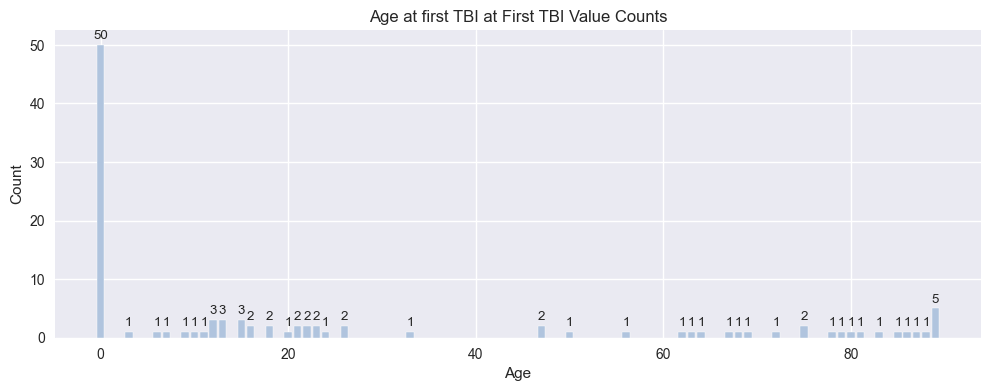

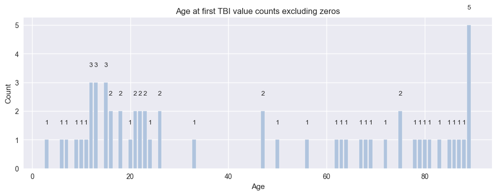

- A significant number of TBI incidents occur during early stages of life, as the majority of donors encounter their initial TBI before reaching the age of 30. Another notable concentration can be observed from the age of 60 onwards.
- To reflect this observation, we will establish three categories: early, mid, late:
  - 1 <= age <= 30: "early_years (1-30)"
  - 31 <= age <= 60: "mid_years (31-60)"
  - 61 <= age <= 90:l "late_years (61-90)"
  - Otherwise "NA"

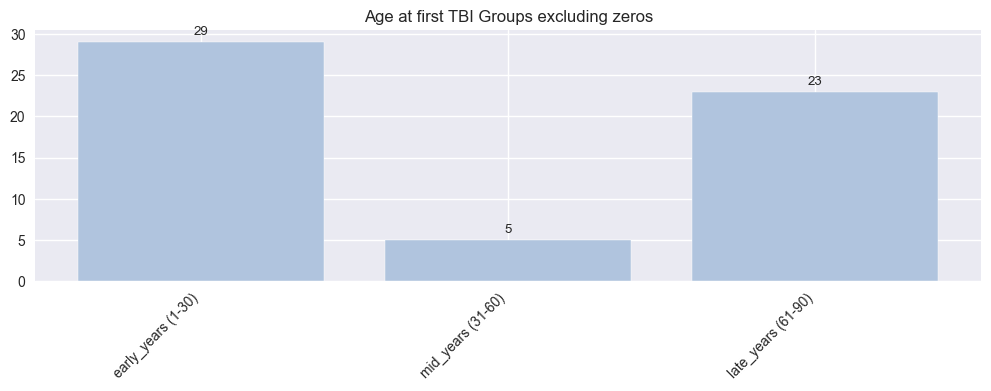

#### education_years - education stages

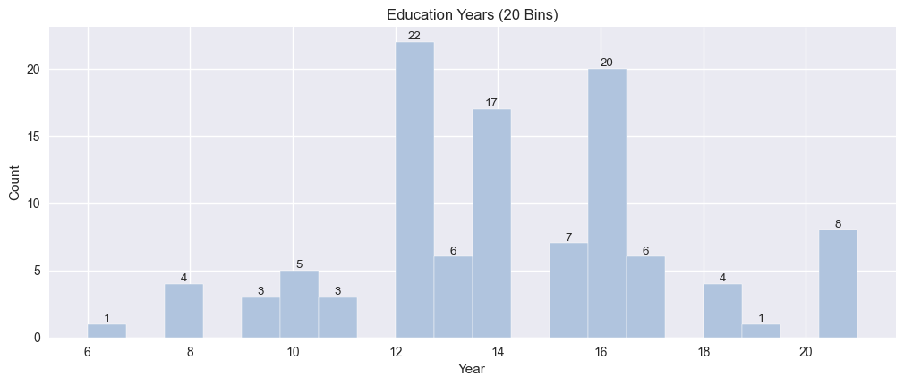

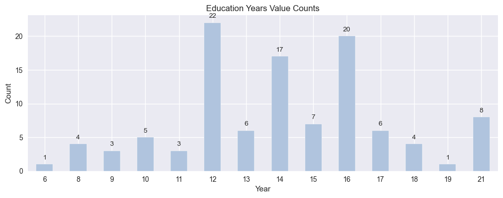

- The most common education duration is 12 years, which typically corresponds to the completion of high school in many education systems.
- The mean years of education is slightly over 14 years, indicating that, on average, the donors have some education beyond high school.
- The wide range, from 6 to 21 years, shows a diverse group of donors in terms of educational background.

We are creating an education years grouping which follows the typical educational stages in the US:

- 'Less than High School (0-11 years)'
- 'High School Graduate (12 years)'
- 'Some College (no degree) (13-15 years)'
- "Associate's or Bachelor's Degree (16-18 years)"
- 'Graduate or Professional Degree (19+ years)

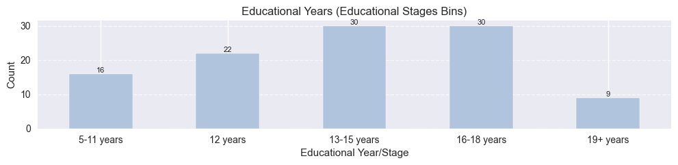

#### education years - quartiles binning

We're also generating quartile-based bins (creating 4 equally sized bins) for a better distribution of the feature:

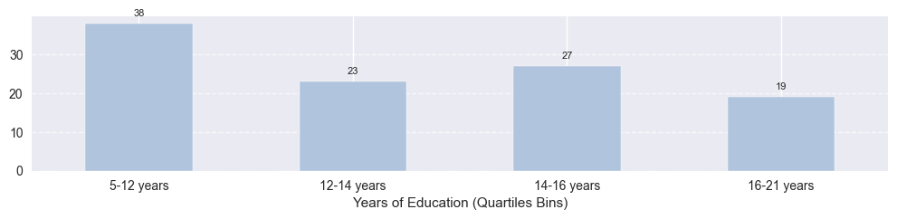

#### longest_loc_duration value counts

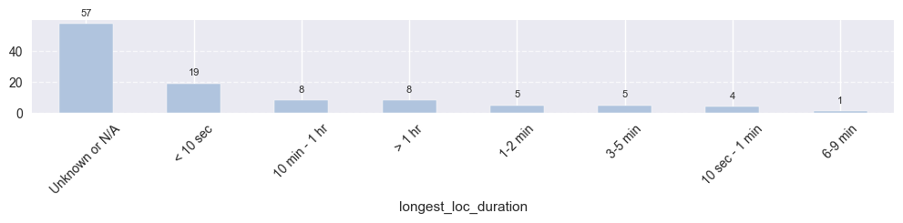

|  | name | donor_id | num_tbi_w_loc | ever_tbi_w_loc | longest_loc_duration | cerad | apo_e4_allele |
| --- | --- | --- | --- | --- | --- | --- | --- |
| 13 | H14.09.093 | 326765680 | 1 | Y | Unknown or N/A | 3 | N |
| 25 | H14.09.055 | 309335492 | 1 | Y | Unknown or N/A | 2 | N |
| 48 | H14.09.099 | 326765686 | 3 | Y | Unknown or N/A | 1 | N |
| 68 | H14.09.059 | 309335496 | 1 | Y | Unknown or N/A | 0 | N |
| 93 | H14.09.081 | 326765668 | 1 | Y | Unknown or N/A | 2 | Y |
| 96 | H14.09.097 | 326765684 | 1 | Y | Unknown or N/A | 1 | N |
| 106 | H14.09.005 | 309335442 | 2 | Y | Unknown or N/A | 1 | Y |

```
(7, 7)
```

|  | name | donor_id | num_tbi_w_loc | ever_tbi_w_loc | longest_loc_duration | cerad |
| --- | --- | --- | --- | --- | --- | --- |
| 0 | H14.09.078 | 326765665 | 0 | N | Unknown or N/A | 0 |
| 4 | H14.09.010 | 309335447 | 0 | N | Unknown or N/A | 3 |
| 5 | H14.09.020 | 309335457 | 0 | N | Unknown or N/A | 2 |
| 7 | H14.09.094 | 326765681 | 0 | N | Unknown or N/A | 1 |
| 9 | H14.09.070 | 326765657 | 0 | N | Unknown or N/A | 0 |
| 10 | H14.09.006 | 309335443 | 0 | N | Unknown or N/A | 0 |
| 12 | H14.09.074 | 326765661 | 0 | N | Unknown or N/A | 1 |
| 19 | H14.09.008 | 309335445 | 0 | N | Unknown or N/A | 3 |
| 22 | H14.09.032 | 309335469 | 0 | N | Unknown or N/A | 1 |
| 23 | H15.09.110 | 467056409 | 0 | N | Unknown or N/A | 2 |
| 24 | H14.09.004 | 309335441 | 0 | N | Unknown or N/A | 1 |
| 28 | H14.09.024 | 309335461 | 0 | N | Unknown or N/A | 1 |
| 29 | H14.09.042 | 309335479 | 0 | N | Unknown or N/A | 3 |
| 32 | H14.09.054 | 309335491 | 0 | N | Unknown or N/A | 1 |
| 34 | H14.09.060 | 309335497 | 0 | N | Unknown or N/A | 2 |
| 35 | H14.09.082 | 326765669 | 0 | N | Unknown or N/A | 0 |
| 36 | H14.09.058 | 309335495 | 0 | N | Unknown or N/A | 1 |
| 37 | H14.09.028 | 309335465 | 0 | N | Unknown or N/A | 2 |
| 38 | H14.09.098 | 326765685 | 0 | N | Unknown or N/A | 3 |
| 40 | H14.09.062 | 326765649 | 0 | N | Unknown or N/A | 1 |
| 41 | H14.09.044 | 309335481 | 0 | N | Unknown or N/A | 2 |
| 42 | H14.09.066 | 326765653 | 0 | N | Unknown or N/A | 0 |
| 43 | H14.09.030 | 309335467 | 0 | N | Unknown or N/A | 3 |
| 44 | H14.09.088 | 326765675 | 0 | N | Unknown or N/A | 3 |
| 45 | H14.09.002 | 309335439 | 0 | N | Unknown or N/A | 0 |
| 49 | H14.09.022 | 309335459 | 0 | N | Unknown or N/A | 0 |
| 50 | H15.09.108 | 467056407 | 0 | N | Unknown or N/A | 3 |
| 53 | H14.09.086 | 326765673 | 0 | N | Unknown or N/A | 3 |
| 56 | H14.09.096 | 326765683 | 0 | N | Unknown or N/A | 2 |
| 60 | H14.09.052 | 309335489 | 0 | N | Unknown or N/A | 1 |
| 61 | H14.09.012 | 309335449 | 0 | N | Unknown or N/A | 0 |
| 65 | H14.09.084 | 326765671 | 0 | N | Unknown or N/A | 0 |
| 69 | H14.09.026 | 309335463 | 0 | N | Unknown or N/A | 2 |
| 70 | H14.09.102 | 326765689 | 0 | N | Unknown or N/A | 0 |
| 75 | H14.09.014 | 309335451 | 0 | N | Unknown or N/A | 1 |
| 77 | H14.09.050 | 309335487 | 0 | N | Unknown or N/A | 3 |
| 78 | H14.09.090 | 326765677 | 0 | N | Unknown or N/A | 1 |
| 80 | H14.09.048 | 309335485 | 0 | N | Unknown or N/A | 0 |
| 81 | H14.09.046 | 309335483 | 0 | N | Unknown or N/A | 2 |
| 82 | H14.09.092 | 326765679 | 0 | N | Unknown or N/A | 3 |
| 83 | H14.09.100 | 326765687 | 0 | N | Unknown or N/A | 2 |
| 84 | H15.09.104 | 467056397 | 0 | N | Unknown or N/A | 2 |
| 86 | H14.09.080 | 326765667 | 0 | N | Unknown or N/A | 0 |
| 88 | H14.09.056 | 309335493 | 0 | N | Unknown or N/A | 3 |
| 91 | H14.09.068 | 326765655 | 0 | N | Unknown or N/A | 3 |
| 92 | H14.09.040 | 309335477 | 0 | N | Unknown or N/A | 1 |
| 95 | H15.09.106 | 467056405 | 0 | N | Unknown or N/A | 0 |
| 97 | H14.09.076 | 326765663 | 0 | N | Unknown or N/A | 1 |
| 100 | H14.09.064 | 326765651 | 0 | N | Unknown or N/A | 2 |
| 101 | H14.09.016 | 309335453 | 0 | N | Unknown or N/A | 2 |

```
(50, 6)
```

- We have 7 records where a TBI event was recorded, however, the longest_loc_duration is "Unknown or N/A". For these records, we set the longest duration to -1
- We have 50 records with no TBI, for those we set the longest_loc_duration to 0

We're merging different groups to achieve a more balanced distribution:

- Combining "10 sec - 1 min" with "1-2 min" to create "10 sec - 2 min".
- Combining "6-9 min" with "10 min - 1 hr" to create "6 min - 1 hr".
- Further combining "10 sec - 2 min" with "3-5 min" to create "10 sec - 5 min".

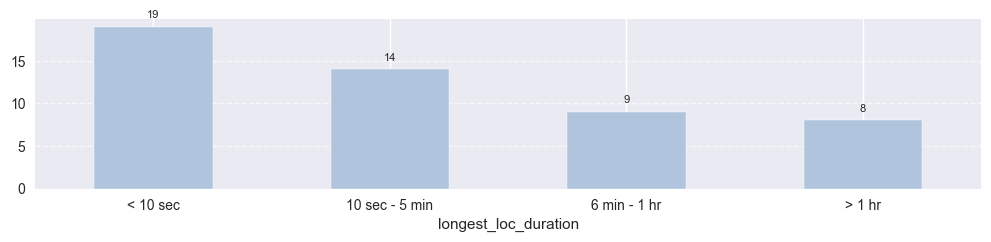

#### longest_loc_duration cleaning

- We are also generating a new attribute called "longest_loc_duration_clean" to retain the quantitative data of the longest_loc_duration.
- We convert all time ranges to seconds and use the median.

|  | donor_id | name | age | sex | apo_e4_allele | education_years | age_at_first_tbi | longest_loc_duration | cerad | num_tbi_w_loc | dsm_iv_clinical_diagnosis | control_set | nincds_arda_diagnosis | ever_tbi_w_loc | race | hispanic | act_demented | braak | nia_reagan | age_bin | age_clean | age_at_first_tbi_bin | education_years_stages_bin | education_years_quartiles_bin | longest_loc_duration_bin | longest_loc_duration_clean |
| --- | --- | --- | --- | --- | --- | --- | --- | --- | --- | --- | --- | --- | --- | --- | --- | --- | --- | --- | --- | --- | --- | --- | --- | --- | --- | --- |
| 13 | 326765680 | H14.09.093 | 77 | M | N | 12 | 12 | Unknown or N/A | 3 | 1 | Other or Unknown Cause | 46 | Dementia, Type Unknown | Y | White | Not Hispanic | Dementia | 6 | 3 | 77-79 | 77.000 | early_years (1-30) | 12 years | 5-12 years | Unknown or N/A | Unknown or N/A |
| 25 | 309335492 | H14.09.055 | 100+ | F | N | 12 | 89 | Unknown or N/A | 2 | 1 | Alzheimer's Disease Type | 18 | Possible Alzheimer'S Disease | Y | White | Not Hispanic | Dementia | 6 | 2 | 100+ | 101.000 | late_years (61-90) | 12 years | 5-12 years | Unknown or N/A | Unknown or N/A |
| 48 | 326765686 | H14.09.099 | 90-94 | M | N | 21 | 88 | Unknown or N/A | 1 | 3 | Alzheimer's Disease Type | 50 | Possible Alzheimer'S Disease | Y | White | Not Hispanic | Dementia | 3 | 1 | 90-94 | 92.000 | late_years (61-90) | 19+ years | 16-21 years | Unknown or N/A | Unknown or N/A |
| 68 | 309335496 | H14.09.059 | 86 | F | N | 11 | 26 | Unknown or N/A | 0 | 1 | Other Medical | 20 | Dementia, Type Unknown | Y | White | Not Hispanic | Dementia | 4 | 1 | 81-86 | 86.000 | early_years (1-30) | 5-11 years | 5-12 years | Unknown or N/A | Unknown or N/A |
| 93 | 326765668 | H14.09.081 | 95-99 | M | Y | 13 | 89 | Unknown or N/A | 2 | 1 | No Dementia | 35 | No Dementia | Y | White | Not Hispanic | No Dementia | 3 | 2 | 95-99 | 97.000 | late_years (61-90) | 13-15 years | 12-14 years | Unknown or N/A | Unknown or N/A |
| 96 | 326765684 | H14.09.097 | 86 | M | N | 14 | 20 | Unknown or N/A | 1 | 1 | No Dementia | 48 | No Dementia | Y | White | Not Hispanic | No Dementia | 3 | 1 | 81-86 | 86.000 | early_years (1-30) | 13-15 years | 12-14 years | Unknown or N/A | Unknown or N/A |
| 106 | 309335442 | H14.09.005 | 90-94 | F | Y | 14 | 3 | Unknown or N/A | 1 | 2 | Multiple Etiologies | 16 | Possible Alzheimer'S Disease | Y | White | Not Hispanic | Dementia | 5 | 2 | 90-94 | 92.000 | early_years (1-30) | 13-15 years | 12-14 years | Unknown or N/A | Unknown or N/A |

|  | name | donor_id | num_tbi_w_loc | ever_tbi_w_loc | longest_loc_duration | longest_loc_duration_clean | cerad | apo_e4_allele |
| --- | --- | --- | --- | --- | --- | --- | --- | --- |
| 0 | H14.09.078 | 326765665 | 0 | N | Unknown or N/A | 0 | 0 | N |
| 4 | H14.09.010 | 309335447 | 0 | N | Unknown or N/A | 0 | 3 | Y |
| 5 | H14.09.020 | 309335457 | 0 | N | Unknown or N/A | 0 | 2 | N |
| 7 | H14.09.094 | 326765681 | 0 | N | Unknown or N/A | 0 | 1 | N |
| 9 | H14.09.070 | 326765657 | 0 | N | Unknown or N/A | 0 | 0 | N |
| 10 | H14.09.006 | 309335443 | 0 | N | Unknown or N/A | 0 | 0 | N |
| 12 | H14.09.074 | 326765661 | 0 | N | Unknown or N/A | 0 | 1 | N |
| 19 | H14.09.008 | 309335445 | 0 | N | Unknown or N/A | 0 | 3 | N |
| 22 | H14.09.032 | 309335469 | 0 | N | Unknown or N/A | 0 | 1 | N |
| 23 | H15.09.110 | 467056409 | 0 | N | Unknown or N/A | 0 | 2 | N |
| 24 | H14.09.004 | 309335441 | 0 | N | Unknown or N/A | 0 | 1 | N |
| 28 | H14.09.024 | 309335461 | 0 | N | Unknown or N/A | 0 | 1 | N |
| 29 | H14.09.042 | 309335479 | 0 | N | Unknown or N/A | 0 | 3 | Unknown |
| 32 | H14.09.054 | 309335491 | 0 | N | Unknown or N/A | 0 | 1 | N |
| 34 | H14.09.060 | 309335497 | 0 | N | Unknown or N/A | 0 | 2 | Unknown |
| 35 | H14.09.082 | 326765669 | 0 | N | Unknown or N/A | 0 | 0 | N |
| 36 | H14.09.058 | 309335495 | 0 | N | Unknown or N/A | 0 | 1 | N |
| 37 | H14.09.028 | 309335465 | 0 | N | Unknown or N/A | 0 | 2 | N |
| 38 | H14.09.098 | 326765685 | 0 | N | Unknown or N/A | 0 | 3 | N |
| 40 | H14.09.062 | 326765649 | 0 | N | Unknown or N/A | 0 | 1 | Y |
| 41 | H14.09.044 | 309335481 | 0 | N | Unknown or N/A | 0 | 2 | Unknown |
| 42 | H14.09.066 | 326765653 | 0 | N | Unknown or N/A | 0 | 0 | N |
| 43 | H14.09.030 | 309335467 | 0 | N | Unknown or N/A | 0 | 3 | Y |
| 44 | H14.09.088 | 326765675 | 0 | N | Unknown or N/A | 0 | 3 | N |
| 45 | H14.09.002 | 309335439 | 0 | N | Unknown or N/A | 0 | 0 | Y |
| 49 | H14.09.022 | 309335459 | 0 | N | Unknown or N/A | 0 | 0 | N |
| 50 | H15.09.108 | 467056407 | 0 | N | Unknown or N/A | 0 | 3 | N |
| 53 | H14.09.086 | 326765673 | 0 | N | Unknown or N/A | 0 | 3 | N |
| 56 | H14.09.096 | 326765683 | 0 | N | Unknown or N/A | 0 | 2 | N |
| 60 | H14.09.052 | 309335489 | 0 | N | Unknown or N/A | 0 | 1 | N |
| 61 | H14.09.012 | 309335449 | 0 | N | Unknown or N/A | 0 | 0 | Y |
| 65 | H14.09.084 | 326765671 | 0 | N | Unknown or N/A | 0 | 0 | N |
| 69 | H14.09.026 | 309335463 | 0 | N | Unknown or N/A | 0 | 2 | N |
| 70 | H14.09.102 | 326765689 | 0 | N | Unknown or N/A | 0 | 0 | N |
| 75 | H14.09.014 | 309335451 | 0 | N | Unknown or N/A | 0 | 1 | N |
| 77 | H14.09.050 | 309335487 | 0 | N | Unknown or N/A | 0 | 3 | N |
| 78 | H14.09.090 | 326765677 | 0 | N | Unknown or N/A | 0 | 1 | N |
| 80 | H14.09.048 | 309335485 | 0 | N | Unknown or N/A | 0 | 0 | Y |
| 81 | H14.09.046 | 309335483 | 0 | N | Unknown or N/A | 0 | 2 | N |
| 82 | H14.09.092 | 326765679 | 0 | N | Unknown or N/A | 0 | 3 | Y |
| 83 | H14.09.100 | 326765687 | 0 | N | Unknown or N/A | 0 | 2 | N |
| 84 | H15.09.104 | 467056397 | 0 | N | Unknown or N/A | 0 | 2 | N |
| 86 | H14.09.080 | 326765667 | 0 | N | Unknown or N/A | 0 | 0 | N |
| 88 | H14.09.056 | 309335493 | 0 | N | Unknown or N/A | 0 | 3 | Unknown |
| 91 | H14.09.068 | 326765655 | 0 | N | Unknown or N/A | 0 | 3 | Y |
| 92 | H14.09.040 | 309335477 | 0 | N | Unknown or N/A | 0 | 1 | Y |
| 95 | H15.09.106 | 467056405 | 0 | N | Unknown or N/A | 0 | 0 | N |
| 97 | H14.09.076 | 326765663 | 0 | N | Unknown or N/A | 0 | 1 | N |
| 100 | H14.09.064 | 326765651 | 0 | N | Unknown or N/A | 0 | 2 | N |
| 101 | H14.09.016 | 309335453 | 0 | N | Unknown or N/A | 0 | 2 | Y |

```
7
```

|  | donor_id | name | age | sex | apo_e4_allele | education_years | age_at_first_tbi | longest_loc_duration | cerad | num_tbi_w_loc | dsm_iv_clinical_diagnosis | control_set | nincds_arda_diagnosis | ever_tbi_w_loc | race | hispanic | act_demented | braak | nia_reagan | age_bin | age_clean | age_at_first_tbi_bin | education_years_stages_bin | education_years_quartiles_bin | longest_loc_duration_bin | longest_loc_duration_clean |
| --- | --- | --- | --- | --- | --- | --- | --- | --- | --- | --- | --- | --- | --- | --- | --- | --- | --- | --- | --- | --- | --- | --- | --- | --- | --- | --- |
| 0 | 326765665 | H14.09.078 | 87 | M | N | 16 | 0 | Unknown or N/A | 0 | 0 | No Dementia | 31 | No Dementia | N | White | Not Hispanic | No Dementia | 1 | 1 | 87-89 | 87.000 | NA | 16-18 years | 14-16 years | Unknown or N/A | 0 |
| 4 | 309335447 | H14.09.010 | 100+ | M | Y | 16 | 0 | Unknown or N/A | 3 | 0 | Alzheimer's Disease Type | 28 | Possible Alzheimer'S Disease | N | White | Not Hispanic | Dementia | 4 | 2 | 100+ | 101.000 | NA | 16-18 years | 14-16 years | Unknown or N/A | 0 |
| 5 | 309335457 | H14.09.020 | 95-99 | F | N | 18 | 0 | Unknown or N/A | 2 | 0 | No Dementia | 1 | No Dementia | N | Non-white | Not Hispanic | No Dementia | 3 | 2 | 95-99 | 97.000 | NA | 16-18 years | 16-21 years | Unknown or N/A | 0 |
| 7 | 326765681 | H14.09.094 | 78 | M | N | 18 | 0 | Unknown or N/A | 1 | 0 | No Dementia | 46 | No Dementia | N | White | Not Hispanic | No Dementia | 2 | 1 | 77-79 | 78.000 | NA | 16-18 years | 16-21 years | Unknown or N/A | 0 |
| 9 | 326765657 | H14.09.070 | 95-99 | M | N | 16 | 0 | Unknown or N/A | 0 | 0 | No Dementia | 26 | No Dementia | N | White | Not Hispanic | No Dementia | 2 | 1 | 95-99 | 97.000 | NA | 16-18 years | 14-16 years | Unknown or N/A | 0 |
| 10 | 309335443 | H14.09.006 | 90-94 | F | N | 14 | 0 | Unknown or N/A | 0 | 0 | No Dementia | 16 | No Dementia | N | White | Not Hispanic | No Dementia | 3 | 1 | 90-94 | 92.000 | NA | 13-15 years | 12-14 years | Unknown or N/A | 0 |
| 12 | 326765661 | H14.09.074 | 82 | F | N | 16 | 0 | Unknown or N/A | 1 | 0 | No Dementia | 29 | No Dementia | N | White | Not Hispanic | No Dementia | 3 | 1 | 81-86 | 82.000 | NA | 16-18 years | 14-16 years | Unknown or N/A | 0 |
| 19 | 309335445 | H14.09.008 | 90-94 | M | N | 9 | 0 | Unknown or N/A | 3 | 0 | Multiple Etiologies | 17 | Possible Alzheimer'S Disease | N | White | Not Hispanic | Dementia | 6 | 3 | 90-94 | 92.000 | NA | 5-11 years | 5-12 years | Unknown or N/A | 0 |
| 22 | 309335469 | H14.09.032 | 90-94 | F | N | 15 | 0 | Unknown or N/A | 1 | 0 | No Dementia | 4 | No Dementia | N | White | Not Hispanic | No Dementia | 4 | 1 | 90-94 | 92.000 | NA | 13-15 years | 14-16 years | Unknown or N/A | 0 |
| 23 | 467056409 | H15.09.110 | 82 | F | N | 14 | 0 | Unknown or N/A | 2 | 0 | Alzheimer's Disease Type | 55 | Probable Alzheimer'S Disease | N | White | Not Hispanic | Dementia | 2 | 1 | 81-86 | 82.000 | NA | 13-15 years | 12-14 years | Unknown or N/A | 0 |
| 24 | 309335441 | H14.09.004 | 90-94 | M | N | 14 | 0 | Unknown or N/A | 1 | 0 | No Dementia | 14 | No Dementia | N | White | Not Hispanic | No Dementia | 3 | 1 | 90-94 | 92.000 | NA | 13-15 years | 12-14 years | Unknown or N/A | 0 |
| 28 | 309335461 | H14.09.024 | 78 | M | N | 21 | 0 | Unknown or N/A | 1 | 0 | No Dementia | 37 | No Dementia | N | White | Not Hispanic | No Dementia | 3 | 1 | 77-79 | 78.000 | NA | 19+ years | 16-21 years | Unknown or N/A | 0 |
| 29 | 309335479 | H14.09.042 | 95-99 | F | Unknown | 11 | 0 | Unknown or N/A | 3 | 0 | Alzheimer's Disease Type | 8 | Possible Alzheimer'S Disease | N | White | Not Hispanic | Dementia | 5 | 3 | 95-99 | 97.000 | NA | 5-11 years | 5-12 years | Unknown or N/A | 0 |
| 32 | 309335491 | H14.09.054 | 89 | M | N | 9 | 0 | Unknown or N/A | 1 | 0 | Alzheimer's Disease Type | 15 | Probable Alzheimer'S Disease | N | White | Not Hispanic | Dementia | 3 | 1 | 87-89 | 89.000 | NA | 5-11 years | 5-12 years | Unknown or N/A | 0 |
| 34 | 309335497 | H14.09.060 | 86 | F | Unknown | 12 | 0 | Unknown or N/A | 2 | 0 | No Dementia | 20 | No Dementia | N | Non-white | Not Hispanic | No Dementia | 4 | 2 | 81-86 | 86.000 | NA | 12 years | 5-12 years | Unknown or N/A | 0 |
| 35 | 326765669 | H14.09.082 | 95-99 | M | N | 15 | 0 | Unknown or N/A | 0 | 0 | Alzheimer's Disease Type | 35 | Possible Alzheimer'S Disease | N | White | Not Hispanic | Dementia | 4 | 1 | 95-99 | 97.000 | NA | 13-15 years | 14-16 years | Unknown or N/A | 0 |
| 36 | 309335495 | H14.09.058 | 88 | M | N | 14 | 0 | Unknown or N/A | 1 | 0 | No Dementia | 19 | No Dementia | N | White | Not Hispanic | No Dementia | 1 | 1 | 87-89 | 88.000 | NA | 13-15 years | 12-14 years | Unknown or N/A | 0 |
| 37 | 309335465 | H14.09.028 | 78 | M | N | 16 | 0 | Unknown or N/A | 2 | 0 | No Dementia | 41 | No Dementia | N | White | Not Hispanic | No Dementia | 3 | 2 | 77-79 | 78.000 | NA | 16-18 years | 14-16 years | Unknown or N/A | 0 |
| 38 | 326765685 | H14.09.098 | 86 | M | N | 9 | 0 | Unknown or N/A | 3 | 0 | Alzheimer's Disease Type | 48 | Probable Alzheimer'S Disease | N | White | Not Hispanic | Dementia | 6 | 3 | 81-86 | 86.000 | NA | 5-11 years | 5-12 years | Unknown or N/A | 0 |
| 40 | 326765649 | H14.09.062 | 89 | F | Y | 16 | 0 | Unknown or N/A | 1 | 0 | No Dementia | 22 | No Dementia | N | White | Not Hispanic | No Dementia | 3 | 1 | 87-89 | 89.000 | NA | 16-18 years | 14-16 years | Unknown or N/A | 0 |
| 41 | 309335481 | H14.09.044 | 87 | F | Unknown | 14 | 0 | Unknown or N/A | 2 | 0 | Alzheimer's Disease Type | 9 | Probable Alzheimer'S Disease | N | White | Not Hispanic | Dementia | 6 | 2 | 87-89 | 87.000 | NA | 13-15 years | 12-14 years | Unknown or N/A | 0 |
| 42 | 326765653 | H14.09.066 | 90-94 | M | N | 12 | 0 | Unknown or N/A | 0 | 0 | Multiple Etiologies | 24 | Possible Alzheimer'S Disease | N | White | Not Hispanic | Dementia | 3 | 1 | 90-94 | 92.000 | NA | 12 years | 5-12 years | Unknown or N/A | 0 |
| 43 | 309335467 | H14.09.030 | 90-94 | F | Y | 15 | 0 | Unknown or N/A | 3 | 0 | No Dementia | 3 | No Dementia | N | White | Not Hispanic | No Dementia | 3 | 2 | 90-94 | 92.000 | NA | 13-15 years | 14-16 years | Unknown or N/A | 0 |
| 44 | 326765675 | H14.09.088 | 100+ | F | N | 12 | 0 | Unknown or N/A | 3 | 0 | Alzheimer's Disease Type | 42 | Possible Alzheimer'S Disease | N | White | Not Hispanic | Dementia | 5 | 3 | 100+ | 101.000 | NA | 12 years | 5-12 years | Unknown or N/A | 0 |
| 45 | 309335439 | H14.09.002 | 90-94 | M | Y | 16 | 0 | Unknown or N/A | 0 | 0 | Alzheimer's Disease Type | 2 | Probable Alzheimer'S Disease | N | White | Not Hispanic | Dementia | 1 | 1 | 90-94 | 92.000 | NA | 16-18 years | 14-16 years | Unknown or N/A | 0 |
| 49 | 309335459 | H14.09.022 | 88 | M | N | 12 | 0 | Unknown or N/A | 0 | 0 | Alzheimer's Disease Type | 21 | Probable Alzheimer'S Disease | N | White | Not Hispanic | Dementia | 1 | 1 | 87-89 | 88.000 | NA | 12 years | 5-12 years | Unknown or N/A | 0 |
| 50 | 467056407 | H15.09.108 | 90-94 | F | N | 12 | 0 | Unknown or N/A | 3 | 0 | No Dementia | 54 | No Dementia | N | White | Not Hispanic | No Dementia | 4 | 2 | 90-94 | 92.000 | NA | 12 years | 5-12 years | Unknown or N/A | 0 |
| 53 | 326765673 | H14.09.086 | 95-99 | F | N | 14 | 0 | Unknown or N/A | 3 | 0 | Alzheimer's Disease Type | 39 | Probable Alzheimer'S Disease | N | White | Not Hispanic | Dementia | 6 | 3 | 95-99 | 97.000 | NA | 13-15 years | 12-14 years | Unknown or N/A | 0 |
| 56 | 326765683 | H14.09.096 | 84 | M | N | 12 | 0 | Unknown or N/A | 2 | 0 | No Dementia | 47 | No Dementia | N | White | Not Hispanic | No Dementia | 3 | 2 | 81-86 | 84.000 | NA | 12 years | 5-12 years | Unknown or N/A | 0 |
| 60 | 309335489 | H14.09.052 | 90-94 | F | N | 14 | 0 | Unknown or N/A | 1 | 0 | No Dementia | 13 | No Dementia | N | White | Not Hispanic | No Dementia | 2 | 1 | 90-94 | 92.000 | NA | 13-15 years | 12-14 years | Unknown or N/A | 0 |
| 61 | 309335449 | H14.09.012 | 86 | F | Y | 16 | 0 | Unknown or N/A | 0 | 0 | Multiple Etiologies | 32 | Possible Alzheimer'S Disease | N | White | Not Hispanic | Dementia | 3 | 1 | 81-86 | 86.000 | NA | 16-18 years | 14-16 years | Unknown or N/A | 0 |
| 65 | 326765671 | H14.09.084 | 81 | M | N | 10 | 0 | Unknown or N/A | 0 | 0 | No Dementia | 38 | No Dementia | N | White | Not Hispanic | No Dementia | 1 | 1 | 81-86 | 81.000 | NA | 5-11 years | 5-12 years | Unknown or N/A | 0 |
| 69 | 309335463 | H14.09.026 | 84 | M | N | 18 | 0 | Unknown or N/A | 2 | 0 | Vascular | 40 | Dementia, Type Unknown | N | White | Not Hispanic | Dementia | 4 | 2 | 81-86 | 84.000 | NA | 16-18 years | 16-21 years | Unknown or N/A | 0 |
| 70 | 326765689 | H14.09.102 | 95-99 | F | N | 16 | 0 | Unknown or N/A | 0 | 0 | No Dementia | 51 | No Dementia | N | White | Not Hispanic | No Dementia | 1 | 1 | 95-99 | 97.000 | NA | 16-18 years | 14-16 years | Unknown or N/A | 0 |
| 75 | 309335451 | H14.09.014 | 90-94 | M | N | 10 | 0 | Unknown or N/A | 1 | 0 | No Dementia | 33 | No Dementia | N | White | Not Hispanic | No Dementia | 4 | 1 | 90-94 | 92.000 | NA | 5-11 years | 5-12 years | Unknown or N/A | 0 |
| 77 | 309335487 | H14.09.050 | 95-99 | M | N | 8 | 0 | Unknown or N/A | 3 | 0 | No Dementia | 12 | No Dementia | N | White | Not Hispanic | No Dementia | 3 | 2 | 95-99 | 97.000 | NA | 5-11 years | 5-12 years | Unknown or N/A | 0 |
| 78 | 326765677 | H14.09.090 | 89 | F | N | 12 | 0 | Unknown or N/A | 1 | 0 | No Dementia | 43 | No Dementia | N | White | Not Hispanic | No Dementia | 5 | 2 | 87-89 | 89.000 | NA | 12 years | 5-12 years | Unknown or N/A | 0 |
| 80 | 309335485 | H14.09.048 | 88 | F | Y | 12 | 0 | Unknown or N/A | 0 | 0 | Multiple Etiologies | 11 | Possible Alzheimer'S Disease | N | White | Not Hispanic | Dementia | 3 | 1 | 87-89 | 88.000 | NA | 12 years | 5-12 years | Unknown or N/A | 0 |
| 81 | 309335483 | H14.09.046 | 95-99 | M | N | 13 | 0 | Unknown or N/A | 2 | 0 | No Dementia | 10 | No Dementia | N | White | Not Hispanic | No Dementia | 1 | 2 | 95-99 | 97.000 | NA | 13-15 years | 12-14 years | Unknown or N/A | 0 |
| 82 | 326765679 | H14.09.092 | 90-94 | M | Y | 14 | 0 | Unknown or N/A | 3 | 0 | Other Medical | 45 | Possible Alzheimer'S Disease | N | White | Not Hispanic | Dementia | 6 | 3 | 90-94 | 92.000 | NA | 13-15 years | 12-14 years | Unknown or N/A | 0 |
| 83 | 326765687 | H14.09.100 | 90-94 | M | N | 12 | 0 | Unknown or N/A | 2 | 0 | Multiple Etiologies | 50 | Possible Alzheimer'S Disease | N | White | Not Hispanic | Dementia | 3 | 2 | 90-94 | 92.000 | NA | 12 years | 5-12 years | Unknown or N/A | 0 |
| 84 | 467056397 | H15.09.104 | 90-94 | F | N | 12 | 0 | Unknown or N/A | 2 | 0 | No Dementia | 52 | No Dementia | N | White | Not Hispanic | No Dementia | 5 | 2 | 90-94 | 92.000 | NA | 12 years | 5-12 years | Unknown or N/A | 0 |
| 86 | 326765667 | H14.09.080 | 87 | M | N | 21 | 0 | Unknown or N/A | 0 | 0 | No Dementia | 34 | No Dementia | N | White | Not Hispanic | No Dementia | 0 | 0 | 87-89 | 87.000 | NA | 19+ years | 16-21 years | Unknown or N/A | 0 |
| 88 | 309335493 | H14.09.056 | 100+ | F | Unknown | 17 | 0 | Unknown or N/A | 3 | 0 | Alzheimer's Disease Type | 18 | Possible Alzheimer'S Disease | N | White | Not Hispanic | Dementia | 5 | 3 | 100+ | 101.000 | NA | 16-18 years | 16-21 years | Unknown or N/A | 0 |
| 91 | 326765655 | H14.09.068 | 85 | M | Y | 16 | 0 | Unknown or N/A | 3 | 0 | Alzheimer's Disease Type | 25 | Probable Alzheimer'S Disease | N | White | Not Hispanic | Dementia | 5 | 3 | 81-86 | 85.000 | NA | 16-18 years | 14-16 years | Unknown or N/A | 0 |
| 92 | 309335477 | H14.09.040 | 85 | M | Y | 12 | 0 | Unknown or N/A | 1 | 0 | Alzheimer's Disease Type | 7 | Probable Alzheimer'S Disease | N | White | Not Hispanic | Dementia | 6 | 2 | 81-86 | 85.000 | NA | 12 years | 5-12 years | Unknown or N/A | 0 |
| 95 | 467056405 | H15.09.106 | 86 | M | N | 14 | 0 | Unknown or N/A | 0 | 0 | No Dementia | 53 | No Dementia | N | White | Not Hispanic | No Dementia | 2 | 1 | 81-86 | 86.000 | NA | 13-15 years | 12-14 years | Unknown or N/A | 0 |
| 97 | 326765663 | H14.09.076 | 78 | F | N | 14 | 0 | Unknown or N/A | 1 | 0 | No Dementia | 30 | No Dementia | N | White | Not Hispanic | No Dementia | 2 | 1 | 77-79 | 78.000 | NA | 13-15 years | 12-14 years | Unknown or N/A | 0 |
| 100 | 326765651 | H14.09.064 | 90-94 | M | N | 12 | 0 | Unknown or N/A | 2 | 0 | Vascular | 23 | Possible Alzheimer'S Disease | N | White | Not Hispanic | Dementia | 2 | 1 | 90-94 | 92.000 | NA | 12 years | 5-12 years | Unknown or N/A | 0 |
| 101 | 309335453 | H14.09.016 | 81 | M | Y | 21 | 0 | Unknown or N/A | 2 | 0 | No Dementia | 36 | No Dementia | N | White | Not Hispanic | No Dementia | 3 | 2 | 81-86 | 81.000 | NA | 19+ years | 16-21 years | Unknown or N/A | 0 |

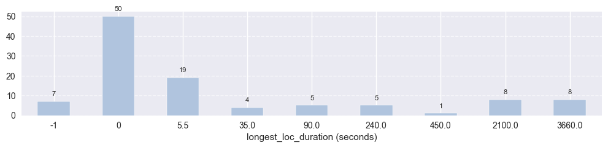

### Clean act_demented

Mapping "No Dementia" to 0 and "Dementia" to 1:

```
act_demented_clean
0    57
1    50
Name: count, dtype: int64
```

### Clean sex

```
sex
M    63
F    44
Name: count, dtype: int64
```

Mapping "F" to 0 and "M" to 1:

```
sex_clean
1    63
0    44
Name: count, dtype: int64
```

### Clean apo_e4_allele

Mapping "N" to 0, "Y" to 1 and "unknown" to -1:

```
apo_e4_allele_clean
 0    80
 1    20
-1     7
Name: count, dtype: int64
```

### Clean ever_tbi_w_loc

Mapping "N" to 0, "Y" to 1:

```
ever_tbi_w_loc_clean
1    57
0    50
Name: count, dtype: int64
```

### Quick value counts check to visually inspect the distributions and available values

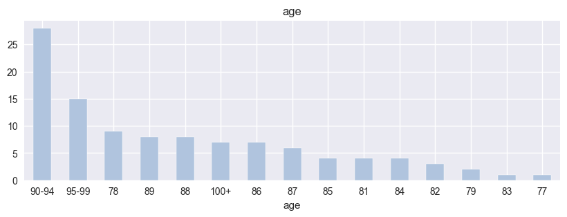

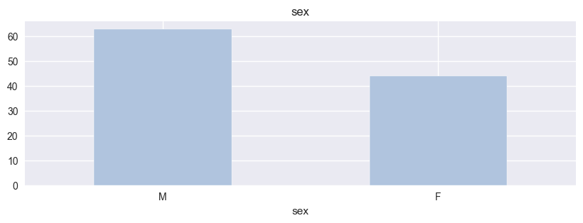

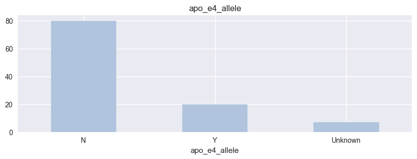

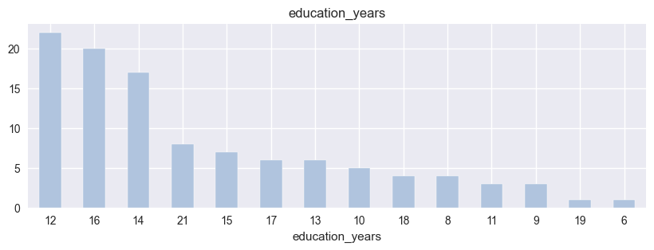

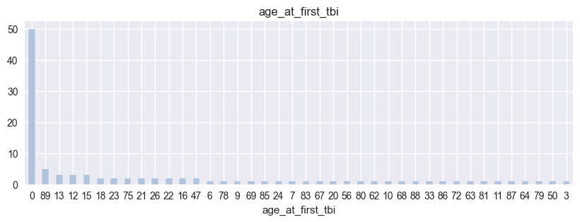

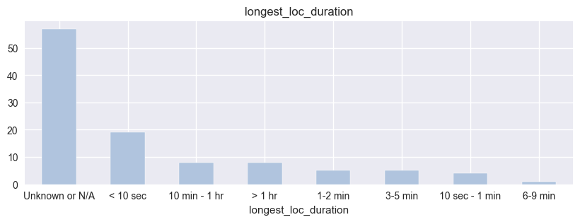

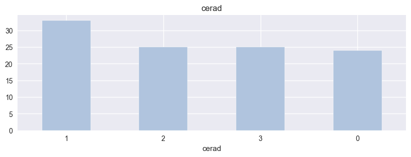

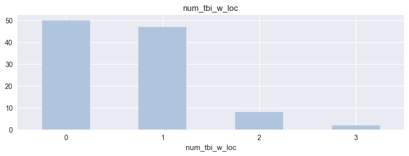

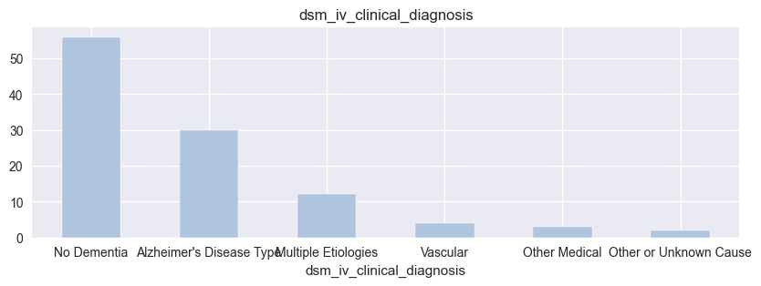

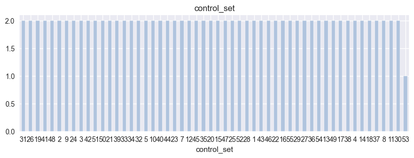

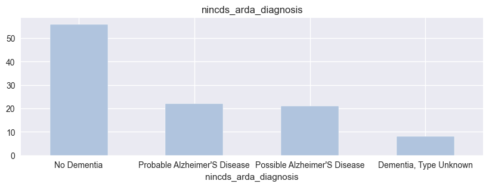

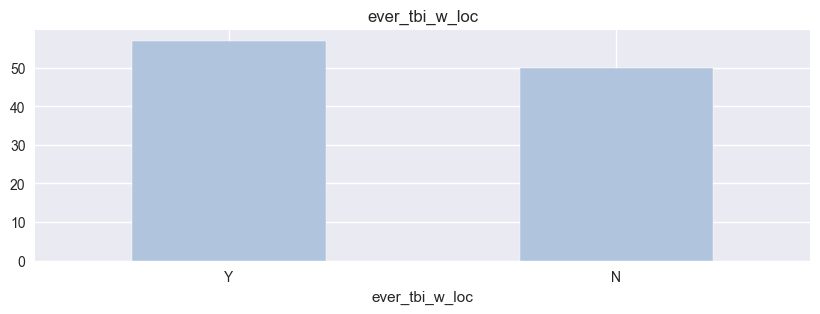

[16 more figures not shown]

### Looking at the control set

|  | donor_id | age | sex | ever_tbi_w_loc | act_demented |
| --- | --- | --- | --- | --- | --- |
| 5 | 309335457 | 95-99 | F | N | No Dementia |
| 66 | 309335456 | 95-99 | F | Y | No Dementia |

|  | donor_id | age | sex | ever_tbi_w_loc | act_demented |
| --- | --- | --- | --- | --- | --- |
| 39 | 309335438 | 90-94 | M | Y | No Dementia |
| 45 | 309335439 | 90-94 | M | N | Dementia |

|  | donor_id | age | sex | ever_tbi_w_loc | act_demented |
| --- | --- | --- | --- | --- | --- |
| 2 | 326765654 | 85 | M | Y | Dementia |
| 91 | 326765655 | 85 | M | N | Dementia |

|  | donor_id | age | sex | ever_tbi_w_loc | act_demented |
| --- | --- | --- | --- | --- | --- |
| 1 | 326765656 | 95-99 | M | Y | No Dementia |
| 9 | 326765657 | 95-99 | M | N | No Dementia |

|  | name | donor_id | age | sex | ever_tbi_w_loc | act_demented |
| --- | --- | --- | --- | --- | --- | --- |
| 95 | H15.09.106 | 467056405 | 86 | M | N | No Dementia |

|  | donor_id | name | age | sex | apo_e4_allele | education_years | age_at_first_tbi | longest_loc_duration | cerad | num_tbi_w_loc | dsm_iv_clinical_diagnosis | control_set | nincds_arda_diagnosis | ever_tbi_w_loc | race | hispanic | act_demented | braak | nia_reagan | age_bin | age_clean | age_at_first_tbi_bin | education_years_stages_bin | education_years_quartiles_bin | longest_loc_duration_bin | longest_loc_duration_clean | act_demented_clean | sex_clean | apo_e4_allele_clean | … |
| --- | --- | --- | --- | --- | --- | --- | --- | --- | --- | --- | --- | --- | --- | --- | --- | --- | --- | --- | --- | --- | --- | --- | --- | --- | --- | --- | --- | --- | --- | --- |
| 0 | 326765665 | H14.09.078 | 87 | M | N | 16 | 0 | Unknown or N/A | 0 | 0 | No Dementia | 31 | No Dementia | N | White | Not Hispanic | No Dementia | 1 | 1 | 87-89 | 87.000 | NA | 16-18 years | 14-16 years | Unknown or N/A | 0 | 0 | 1 | 0 | … |
| 1 | 326765656 | H14.09.069 | 95-99 | M | N | 17 | 12 | 1-2 min | 2 | 1 | No Dementia | 26 | No Dementia | Y | White | Not Hispanic | No Dementia | 5 | 2 | 95-99 | 97.000 | early_years (1-30) | 16-18 years | 16-21 years | 10 sec - 5 min | 90.000 | 0 | 1 | 0 | … |
| 2 | 326765654 | H14.09.067 | 85 | M | Y | 10 | 72 | < 10 sec | 3 | 1 | Vascular | 25 | Dementia, Type Unknown | Y | White | Not Hispanic | Dementia | 4 | 2 | 81-86 | 85.000 | late_years (61-90) | 5-11 years | 5-12 years | < 10 sec | 5.500 | 1 | 1 | 1 | … |
| 3 | 467056391 | H15.09.103 | 90-94 | F | N | 11 | 87 | < 10 sec | 0 | 1 | No Dementia | 52 | No Dementia | Y | White | Not Hispanic | No Dementia | 4 | 0 | 90-94 | 92.000 | late_years (61-90) | 5-11 years | 5-12 years | < 10 sec | 5.500 | 0 | 0 | 0 | … |
| 4 | 309335447 | H14.09.010 | 100+ | M | Y | 16 | 0 | Unknown or N/A | 3 | 0 | Alzheimer's Disease Type | 28 | Possible Alzheimer'S Disease | N | White | Not Hispanic | Dementia | 4 | 2 | 100+ | 101.000 | NA | 16-18 years | 14-16 years | Unknown or N/A | 0 | 1 | 1 | 1 | … |

```
ever_tbi_w_loc
Y    57
N    50
Name: count, dtype: int64
```

```
ever_tbi_w_loc_clean
1    57
0    50
Name: count, dtype: int64
```

## Quick Checks

### Quick Variance Check

```
control_set                                          246.449
age_clean                                             41.008
braak                                                  2.982
cerad                                                  1.176
nia_reagan                                             0.733
num_tbi_w_loc                                          0.495
nincds_arda_diagnosis_No Dementia                      0.252
dsm_iv_clinical_diagnosis_No Dementia                  0.252
ever_tbi_w_loc_Y                                       0.251
longest_loc_duration_bin_Unknown or N/A                0.251
ever_tbi_w_loc_clean                                   0.251
act_demented_No Dementia                               0.251
longest_loc_duration_clean_0.0                         0.251
act_demented_clean                                     0.251
sex_M                                                  0.244
sex_clean                                              0.244
apo_e4_allele_clean                                    0.240
education_years_stages_bin_16-18 years                 0.204
education_years_stages_bin_13-15 years                 0.204
age_at_first_tbi_bin_early_years (1-30)                0.199
age_bin_90-94                                          0.195
education_years_quartiles_bin_14-16 years              0.190
education_years_quartiles_bin_12-14 years              0.170
age_at_first_tbi_bin_late_years (61-90)                0.170
age_bin_81-86                                          0.170
nincds_arda_diagnosis_Probable Alzheimer'S Disease     0.165
education_years_stages_bin_12 years                    0.165
age_bin_87-89                                          0.165
nincds_arda_diagnosis_Possible Alzheimer'S Disease     0.159
apo_e4_allele_Y                                        0.153
education_years_quartiles_bin_16-21 years              0.147
longest_loc_duration_clean_5.5                         0.147
longest_loc_duration_bin_< 10 sec                      0.147
age_bin_95-99                                          0.122
dsm_iv_clinical_diagnosis_Multiple Etiologies          0.101
age_bin_77-79                                          0.101
longest_loc_duration_bin_6 min - 1 hr                  0.078
education_years_stages_bin_19+ years                   0.078
longest_loc_duration_bin_> 1 hr                        0.070
longest_loc_duration_clean_2100.0                      0.070
longest_loc_duration_clean_3660.0                      0.070
apo_e4_allele_Unknown                                  0.062
longest_loc_duration_clean_90.0                        0.045
age_at_first_tbi_bin_mid_years (31-60)                 0.045
longest_loc_duration_clean_240.0                       0.045
dsm_iv_clinical_diagnosis_Vascular                     0.036
longest_loc_duration_clean_35.0                        0.036
dsm_iv_clinical_diagnosis_Other Medical                0.028
dsm_iv_clinical_diagnosis_Other or Unknown Cause       0.019
race_White                                             0.019
longest_loc_duration_clean_450.0                       0.009
dtype: float64
```

### Quick Correlation Check

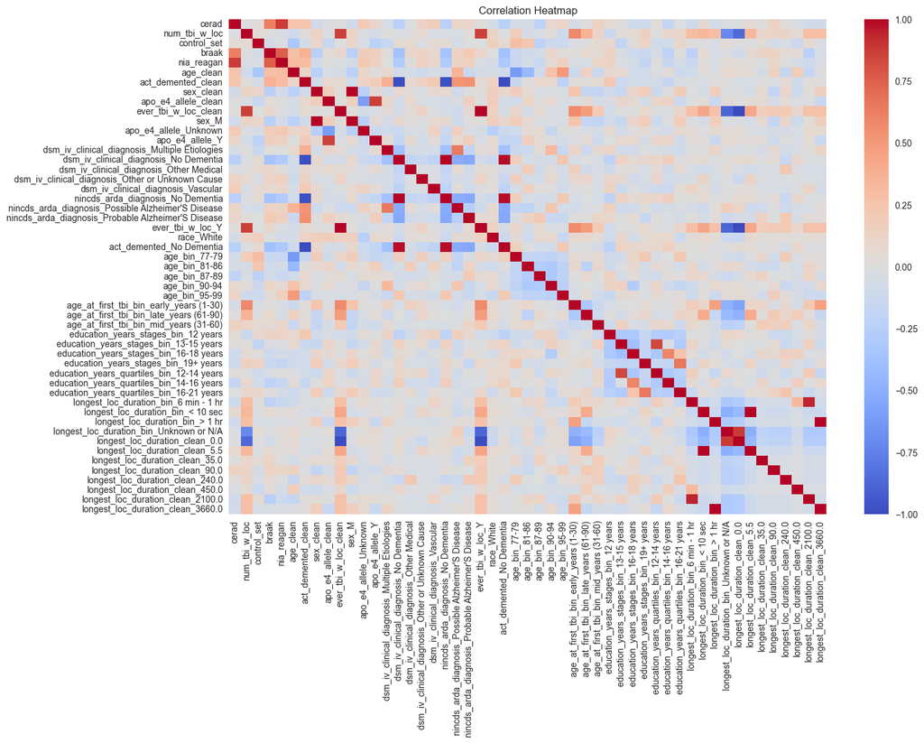

#### Most significant correlations (top 10)

|  | Variable1 | Variable2 | Correlation |
| --- | --- | --- | --- |
| 2214 | longest_loc_duration_clean_0.0 | ever_tbi_w_loc_Y | -1.000 |
| 2202 | longest_loc_duration_clean_0.0 | ever_tbi_w_loc_clean | -1.000 |
| 1114 | ever_tbi_w_loc_Y | longest_loc_duration_clean_0.0 | -1.000 |
| 502 | ever_tbi_w_loc_clean | longest_loc_duration_clean_0.0 | -1.000 |
| 1179 | act_demented_No Dementia | act_demented_clean | -1.000 |
| 2591 | longest_loc_duration_clean_3660.0 | longest_loc_duration_bin_> 1 hr | 1.000 |
| 517 | sex_M | sex_clean | 1.000 |
| 732 | dsm_iv_clinical_diagnosis_No Dementia | nincds_arda_diagnosis_No Dementia | 1.000 |
| 367 | sex_clean | sex_M | 1.000 |
| 480 | ever_tbi_w_loc_clean | ever_tbi_w_loc_Y | 1.000 |

Dropping highly correlated variables:

- 'dsm_iv_clinical_diagnosis_No Dementia',
- 'nincds_arda_diagnosis_No Dementia',
- 'act_demented_No Dementia',
- we may not want to drop both 'cerad' and 'nia_reagan' since they are not a perfect correlation.
  - 'cerad',

|  | Variable1 | Variable2 | Correlation |
| --- | --- | --- | --- |
| 415 | ever_tbi_w_loc_clean | longest_loc_duration_clean_0.0 | -1.000 |
| 885 | ever_tbi_w_loc_Y | longest_loc_duration_clean_0.0 | -1.000 |
| 854 | ever_tbi_w_loc_Y | ever_tbi_w_loc_clean | 1.000 |
| 429 | sex_M | sex_clean | 1.000 |
| 1732 | longest_loc_duration_bin_< 10 sec | longest_loc_duration_clean_5.5 | 1.000 |
| 1785 | longest_loc_duration_bin_> 1 hr | longest_loc_duration_clean_3660.0 | 1.000 |
| 1690 | longest_loc_duration_bin_6 min - 1 hr | longest_loc_duration_clean_2100.0 | 0.938 |
| 414 | ever_tbi_w_loc_clean | longest_loc_duration_bin_Unknown or N/A | -0.877 |
| 1825 | longest_loc_duration_bin_Unknown or N/A | longest_loc_duration_clean_0.0 | 0.877 |
| 884 | ever_tbi_w_loc_Y | longest_loc_duration_bin_Unknown or N/A | -0.877 |

## Exports

```
<class 'pandas.core.frame.DataFrame'>
RangeIndex: 107 entries, 0 to 106
Data columns (total 30 columns):
 #   Column                         Non-Null Count  Dtype
---  ------                         --------------  -----
 0   donor_id                       107 non-null    int64
 1   name                           107 non-null    object
 2   age                            107 non-null    object
 3   sex                            107 non-null    object
 4   apo_e4_allele                  107 non-null    object
 5   education_years                107 non-null    int64
 6   age_at_first_tbi               107 non-null    int64
 7   longest_loc_duration           107 non-null    object
 8   cerad                          107 non-null    int64
 9   num_tbi_w_loc                  107 non-null    int64
```

[output cut: 22 more lines]

## Watermark

```
Last updated: 2023-11-27T23:37:08.655358+05:30

Python implementation: CPython
Python version       : 3.9.16
IPython version      : 8.16.1

Compiler    : Clang 14.0.6
OS          : Darwin
Release     : 23.1.0
Machine     : arm64
Processor   : arm
CPU cores   : 10
Architecture: 64bit
```

```
pandas    : 2.1.1
numpy     : 1.26.1
seaborn   : 0.13.0
matplotlib: 3.8.0
```

## Snapshot

```
01.01_clean_donorinfo.ipynb
[NbConvertApp] Converting notebook 01.01_clean_donorinfo.ipynb to html
[NbConvertApp] WARNING | Alternative text is missing on 42 image(s).
[NbConvertApp] Writing 1868564 bytes to ../reports/html/2023-11-27_01.01_clean_donorinfo.html
```

```
../reports/html/2023-11-27_01.01_clean_donorinfo_no_code.html
```

```
[NbConvertApp] Converting notebook 01.01_clean_donorinfo.ipynb to html
[NbConvertApp] WARNING | Alternative text is missing on 42 image(s).
[NbConvertApp] Writing 1701801 bytes to ../reports/html/2023-11-27_01.01_clean_donorinfo_no_code.html
```

```
0
```